# project_milestone_1

```python
import pandas as pd
import numpy as np
import matplotlib.pyplot as plt
import string
import re

pd.options.mode.copy_on_write = True
np.random.seed(1)
```

```python
from google.colab import drive
drive.mount('/content/drive')
%cd /content/drive/MyDrive
```

```
/content/drive/MyDrive
```

```python
%%shell
jupyter nbconvert --to html /content/drive/MyDrive/project_milestone_1.ipynb
```

```
[NbConvertApp] Converting notebook /content/drive/MyDrive/project_milestone_1.ipynb to html
[NbConvertApp] WARNING | Alternative text is missing on 3 image(s).
[NbConvertApp] Writing 444615 bytes to /content/drive/MyDrive/project_milestone_1.html
```

# Determining POCs in Women

Nysa Bhat and Madeline Davis

[project website link](https://github.com/madelinefdavis/madelinefdavis.github.io)

# Project Goals

Our final project will focus on Polycystic ovary syndrome (PCOS). This is a hormonal imbalabce that occurs in your ovaries that causes your hormones to produce unusually high levels of androgen. This is one of the most commone causes of female infertility. This condition is common affect arounf 15% of women of reproductive age. Sympotoms of PCOS often include irregular periods, abnormal hair growth, acne, obesity, darkening of the skin, skin tags, thinning hair and infertility. While you cannot sure PCOs there are ways you can manage symptoms so they are less impactful in day to day life.

The data set we are using can be found [here](https://www.kaggle.com/datasets/shreyasvedpathak/pcos-dataset/data). This data set is a survey of 541 women. It indicates whether or not they have a PCOS diagnosis and whether or not they have some of the common indicators of PCOS. For our final project we will be looking at different symptoms of PCOS to see which are the best indicator of having PCOS and are a sign that an individual should go their doctor to discuss potential treatments.

# Collaboration Plan

We will meet every Monday (zoom or in person). During this meeting we will come up with a task list for each of us to make sure we are making progress. When we have milestone due we will meet before we sumbit to go over our work and make sure it is cohesive

```python
import pandas as pd
df = pd.read_csv('/content/drive/MyDrive/pcos_data.csv')
df.head()
```

|  | Sl. No | Patient File No. | has_pcos | Age (yrs) | Weight (Kg) | Height(Cm) | BMI | blood_group | Pulse_rate(bpm) | RR(breaths/min) | Hb(g/dl) | Cycle(R/I) | Cycle_length(days) | Marriage_Status(Yrs) | is_pregnant | No._of _abortions | I_beta-HCG(mIU/mL) | II_beta-HCG(mIU/mL) | FSH(mIU/mL) | LH(mIU/mL) | FSH/LH | Hip(inch) | Waist(inch) | Waist:Hip Ratio | TSH (mIU/L) | AMH(ng/mL) | PRL(ng/mL) | Vit_D3(ng/mL) | PRG(ng/mL) | … |
| --- | --- | --- | --- | --- | --- | --- | --- | --- | --- | --- | --- | --- | --- | --- | --- | --- | --- | --- | --- | --- | --- | --- | --- | --- | --- | --- | --- | --- | --- | --- |
| 0 | 1 | 1 | 0 | 28 | 44.6 | 152.0 | 19.300000 | O+ | 78 | 22 | 10.48 | 2 | 5 | 7.0 | 0 | 0 | 1.99 | 1.99 | 7.95 | 3.68 | 2.160326 | 36 | 30 | 0.833333 | 0.68 | 2.07 | 45.16 | 17.1 | 0.57 | … |
| 1 | 2 | 2 | 0 | 36 | 65.0 | 161.5 | 24.921163 | O+ | 74 | 20 | 11.70 | 2 | 5 | 11.0 | 1 | 0 | 60.80 | 1.99 | 6.73 | 1.09 | 6.174312 | 38 | 32 | 0.842105 | 3.16 | 1.53 | 20.09 | 61.3 | 0.97 | … |
| 2 | 3 | 3 | 1 | 33 | 68.8 | 165.0 | 25.270891 | A+ | 72 | 18 | 11.80 | 2 | 5 | 10.0 | 1 | 0 | 494.08 | 494.08 | 5.54 | 0.88 | 6.295455 | 40 | 36 | 0.900000 | 2.54 | 6.63 | 10.52 | 49.7 | 0.36 | … |
| 3 | 4 | 4 | 0 | 37 | 65.0 | 148.0 | 29.674945 | B+ | 72 | 20 | 12.00 | 2 | 5 | 4.0 | 0 | 0 | 1.99 | 1.99 | 8.06 | 2.36 | 3.415254 | 42 | 36 | 0.857143 | 16.41 | 1.22 | 36.90 | 33.4 | 0.36 | … |
| 4 | 5 | 5 | 0 | 25 | 52.0 | 161.0 | 20.060954 | A+ | 72 | 18 | 10.00 | 2 | 5 | 1.0 | 1 | 0 | 801.45 | 801.45 | 3.98 | 0.90 | 4.422222 | 37 | 30 | 0.810811 | 3.57 | 2.26 | 30.09 | 43.8 | 0.38 | … |

```python
#change columns to correct dtypes
df.drop(columns=["Sl. No"], inplace=True) #redunant wit Patient File No.
df['Patient File No.'] = df['Patient File No.'].astype(object)
binary_cols = [
    "has_pcos", "is_pregnant", "has_weight_gain", "has_hair_growth",
    "has_hyperpigmentation", "has_hair_loss", "has_pimples", "does_exercise"
]
df[binary_cols] = df[binary_cols].astype(bool)
df['Cycle(R/I)']=df['Cycle(R/I)'].astype(object)
df["AMH(ng/mL)"] = pd.to_numeric(df["AMH(ng/mL)"], errors="coerce")
df.dtypes
```

|  | 0 |
| --- | --- |
| Patient File No. | object |
| has_pcos | bool |
| Age (yrs) | int64 |
| Weight (Kg) | float64 |
| Height(Cm) | float64 |
| BMI | float64 |
| blood_group | object |
| Pulse_rate(bpm) | int64 |
| RR(breaths/min) | int64 |
| Hb(g/dl) | float64 |
| Cycle(R/I) | object |
| Cycle_length(days) | int64 |
| Marriage_Status(Yrs) | float64 |
| is_pregnant | bool |
| No._of _abortions | int64 |
| I_beta-HCG(mIU/mL) | float64 |
| II_beta-HCG(mIU/mL) | float64 |
| FSH(mIU/mL) | float64 |
| LH(mIU/mL) | float64 |
| FSH/LH | float64 |
| Hip(inch) | int64 |
| Waist(inch) | int64 |
| Waist:Hip Ratio | float64 |
| TSH (mIU/L) | float64 |
| AMH(ng/mL) | float64 |
| PRL(ng/mL) | float64 |
| Vit_D3(ng/mL) | float64 |
| PRG(ng/mL) | float64 |
| RBS(mg/dl) | float64 |
| has_weight_gain | bool |
| has_hair_growth | bool |
| has_hyperpigmentation | bool |
| has_hair_loss | bool |
| has_pimples | bool |
| eats_fast_food | float64 |
| does_exercise | bool |
| BP _Systolic (mmHg) | int64 |
| BP _Diastolic (mmHg) | int64 |
| Follicle No. (L) | int64 |
| Follicle No. (R) | int64 |
| Avg. F size (L) (mm) | float64 |
| Avg. F size (R) (mm) | float64 |
| Endometrium (mm) | float64 |

**dtype:** object

```python
grouped_counts = df.groupby(['has_pcos', 'Cycle(R/I)']).size().reset_index(name='count')

regularity_mapping = {
    2: 'Regular',
    4: 'Irregular',
    5: 'Amenorrhea'
}
pivot_table = grouped_counts.pivot(index='has_pcos', columns='Cycle(R/I)', values='count')
pivot_table = pivot_table.rename(columns=regularity_mapping)

pivot_table_percentages = pivot_table.div(pivot_table.sum(axis=1), axis=0) * 100

final_table = pd.concat([pivot_table, pivot_table_percentages], keys=['Count', 'Percentage'], axis=1)
final_table['Percentage'] = final_table['Percentage'].round(2)
final_table = final_table.fillna(0)
print(final_table)
```

```
             Count                      Percentage
Cycle(R/I) Regular Irregular Amenorrhea    Regular Irregular Amenorrhea
has_pcos
False        308.0      56.0        0.0      84.62     15.38       0.00
True          82.0      94.0        1.0      46.33     53.11       0.56
```

One of the main symptoms of pcos is having an irregular period. Here I created a pivot table comparing cycle regularity depending on whether or not a patient has PCOS. From this having PCOS does seem to be correlated with an irregular period.

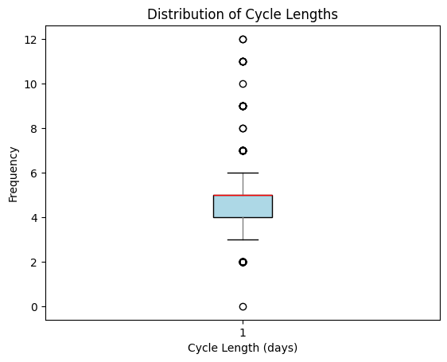

|  | Cycle_length(days) |
| --- | --- |
| count | 541.00 |
| mean | 4.94 |
| std | 1.49 |
| min | 0.00 |
| 25% | 4.00 |
| 50% | 5.00 |
| 75% | 5.00 |
| max | 12.00 |

**dtype:** float64

```python
import matplotlib.pyplot as plt
import seaborn as sns

plt.boxplot(df['Cycle_length(days)'], patch_artist=True,  # Fill the boxes with color
            boxprops=dict(facecolor='lightblue', color='black'),  # Customize box colors
            medianprops=dict(color='red'),  # Customize median line color
            whiskerprops=dict(color='gray'),  # Customize whisker colors
            capprops=dict(color='black'))  # Customize cap colors



# Set labels and title
plt.xlabel('Cycle Length (days)')
plt.ylabel('Frequency')
plt.title('Distribution of Cycle Lengths')

# Display the plot
plt.show()

df['Cycle_length(days)'].describe().round(2)
```

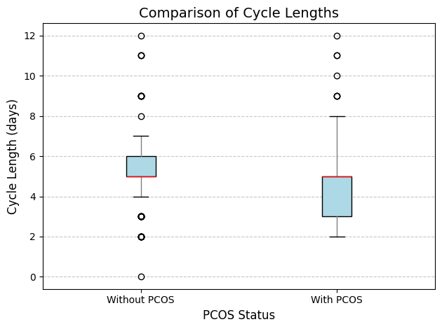

```python
plt.boxplot([df[df['has_pcos'] == 0]['Cycle_length(days)'],
             df[df['has_pcos'] == 1]['Cycle_length(days)']],
            labels=['Without PCOS', 'With PCOS'],
            patch_artist=True,  # Fill the boxes with color
            boxprops=dict(facecolor='lightblue', color='black'),  # Customize box colors
            medianprops=dict(color='red'),  # Customize median line color
            whiskerprops=dict(color='gray'),  # Customize whisker colors
            capprops=dict(color='black'))  # Customize cap colors


plt.xlabel('PCOS Status', fontsize=12)  # Increase font size
plt.ylabel('Cycle Length (days)', fontsize=12)  # Increase font size
plt.title('Comparison of Cycle Lengths', fontsize=14)  # Increase font size

plt.grid(axis='y', linestyle='--', alpha=0.7)  # Add a subtle grid for better readability

plt.tight_layout()  # Adjust layout to prevent overlapping elements
plt.show()
```

```python
without_pcos_stats = df[df['has_pcos'] == 0]['Cycle_length(days)'].describe().round(2)
with_pcos_stats = df[df['has_pcos'] == 1]['Cycle_length(days)'].describe().round(2)

stats_table = pd.concat([without_pcos_stats, with_pcos_stats], axis=1, keys=['Without PCOS', 'With PCOS'])


stats_table.index.name = "Cycle Length Summary Statistics"
stats_table.columns = ["Without PCOS ", "With PCOS"]

display(stats_table)
```

| Cycle Length Summary Statistics | Without PCOS | With PCOS |
| --- | --- | --- |
| count | 364.00 | 177.00 |
| mean | 5.13 | 4.56 |
| std | 1.26 | 1.82 |
| min | 0.00 | 2.00 |
| 25% | 5.00 | 3.00 |
| 50% | 5.00 | 5.00 |
| 75% | 6.00 | 5.00 |
| max | 12.00 | 12.00 |

The tables and charts above look at cycle length. I could tell that your period was more likely to be irregular with PCOS, but I wanted to cycle lengths of patients with and with out POCS. As you can see the mean and median is around the same for individuals with and without PCOS. However, the spread is larger for individuals with PCOS. This makes me think that having PCOS results in longer periods for some women and shorter/lack of period for other women with PCOS

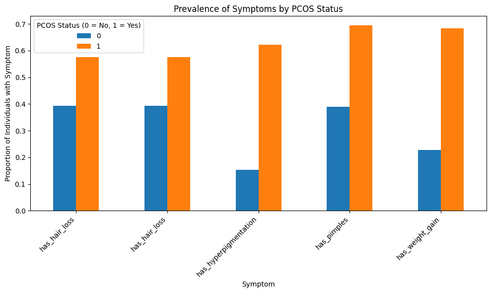

```python
pivot_table = pd.pivot_table(df,
                           index='has_pcos',
                           values=['has_weight_gain','has_hair_loss','has_hyperpigmentation','has_hair_loss','has_pimples'],
                           aggfunc=np.mean # Calculate mean (proportion)
                           )

pivot_table

pivot_table = pivot_table.T

pivot_table.plot(kind='bar', figsize=(10, 6))
plt.title('Prevalence of Symptoms by PCOS Status')
plt.xlabel('Symptom')
plt.ylabel('Proportion of Individuals with Symptom')
plt.xticks(rotation=45, ha='right')  # Rotate x-axis labels for better readability
plt.legend(title='PCOS Status (0 = No, 1 = Yes)')
plt.tight_layout()
plt.show()
```

This is a graph that shows the proportion of women with and without PCOS that show common PCOS symptoms. As you can see have PCOS has a higher proportion for all symptoms. As we continue with this project we will use hypothesis testing to create more concert conclusions on whether or not these symptoms are good indicators of PCOS.